# data.table tips

17 de diciembre de 2015

## Introduction

## what?

Extension of Data.frame i.e. is.data.frame(DT) == TRUE

- Think data.table as a set of columns
- Every column is the same length but different type

## why?

- Reduce programming time, fewer function calls, less variable name repetition
- Fast aggregation of large data (e.g. 100GB in RAM), fast ordered joins, fast add/modify/delete of columns by group using no copies at all, list columns
- Fast file reader (fread).
- Offers a natural and flexible syntax, for faster development.

## how?

## General Form

mtcarsDT[  
mpg > 20 ,  
.(Avgmean = mean( hp ), "minWT(kg)"= min( wt*453.6 )) ,  
by =.(cyl,under5gear = gear < 5 )  
]

R:  
SQL:

i  
where

j  
select

by =  
group by

## Example

Take mtcarsDT , subset using i , then calculate j grouped by by

```r
mtcarsDT <- as.data.table(mtcars)
mtcarsDT[
  mpg > 20,
  .(Avgmean = mean( hp ),
    "minWT(kg)"= min( wt*453.6 )),
  by =.(cyl,under5gear = gear < 5 )
  ]
```

```
##    cyl under5gear   Avgmean minWT(kg)
## 1:   6       TRUE 110.00000 1188.4320
## 2:   4       TRUE  78.33333  732.5640
## 3:   4      FALSE 102.00000  686.2968
```

## Create

```r
DT <- data.table( A = 1:6 , B = c("a","b","c") ,
                  C = rnorm(6) , D = TRUE )
DT
```

```
##    A B           C    D
## 1: 1 a  0.01217364 TRUE
## 2: 2 b -0.67191078 TRUE
## 3: 3 c -1.22528189 TRUE
## 4: 4 a  0.14773944 TRUE
## 5: 5 b  0.39352977 TRUE
## 6: 6 c -1.18455860 TRUE
```

## Print

```r
DT2 <- data.table( A = 1:1000000 , B = letters[1:20] ,
                   C = rnorm(1000000) , D = TRUE)
DT2
```

```
##                A B          C    D
##       1:       1 a  0.1395602 TRUE
##       2:       2 b -1.2623880 TRUE
##       3:       3 c -0.2850492 TRUE
##       4:       4 d  0.3875974 TRUE
##       5:       5 e  1.2440348 TRUE
##      ---
##  999996:  999996 p -0.4301554 TRUE
##  999997:  999997 q  0.5417131 TRUE
##  999998:  999998 r  0.8287077 TRUE
##  999999:  999999 s  0.8368407 TRUE
## 1000000: 1000000 t -0.2069582 TRUE
```

## Subseting

```r
DT[ 3:5 , ] # or DT[ 3:5 ]
```

```
##    A B          C    D
## 1: 3 c -1.2252819 TRUE
## 2: 4 a  0.1477394 TRUE
## 3: 5 b  0.3935298 TRUE
```

```r
DT[ B == "a" ]
```

```
##    A B          C    D
## 1: 1 a 0.01217364 TRUE
## 2: 4 a 0.14773944 TRUE
```

```r
DT[ B %in% c("a","c") ]
```

```
##    A B           C    D
## 1: 1 a  0.01217364 TRUE
## 2: 3 c -1.22528189 TRUE
## 3: 4 a  0.14773944 TRUE
## 4: 6 c -1.18455860 TRUE
```

```r
DT[ between(C,-0.5,0.5) ]
```

```
##    A B          C    D
## 1: 1 a 0.01217364 TRUE
## 2: 4 a 0.14773944 TRUE
## 3: 5 b 0.39352977 TRUE
```

## Selecting columns

```r
DT[, .(B, C)]
```

```
##    B           C
## 1: a  0.01217364
## 2: b -0.67191078
## 3: c -1.22528189
## 4: a  0.14773944
## 5: b  0.39352977
## 6: c -1.18455860
```

NB: .() is an alias to list() in data.tables and they mean the same.

## Computing on columns

```r
DT
```

```
##    A B           C    D
## 1: 1 a  0.01217364 TRUE
## 2: 2 b -0.67191078 TRUE
## 3: 3 c -1.22528189 TRUE
## 4: 4 a  0.14773944 TRUE
## 5: 5 b  0.39352977 TRUE
## 6: 6 c -1.18455860 TRUE
```

```r
DT[, .(Total = sum(A),
       Mean = mean(C))]
```

```
##    Total       Mean
## 1:    21 -0.4213847
```

```r
DT[, .(paste0(B,collapse=""))]
```

```
##        V1
## 1: abcabc
```

## Recycling

```r
DT[, .(B,C=sum(C))]
```

```
##    B         C
## 1: a -2.528308
## 2: b -2.528308
## 3: c -2.528308
## 4: a -2.528308
## 5: b -2.528308
## 6: c -2.528308
```

## Assignments (:=)

```r
DT2[ , c("mean_A","sum_c"):=list(mean(A),sum(C)) ,by=B ]
DT2
```

```
##                A B          C    D mean_A      sum_c
##       1:       1 a  0.1395602 TRUE 499991 -105.18562
##       2:       2 b -1.2623880 TRUE 499992   59.95582
##       3:       3 c -0.2850492 TRUE 499993  253.31572
##       4:       4 d  0.3875974 TRUE 499994 -413.86996
##       5:       5 e  1.2440348 TRUE 499995  -21.75790
##      ---
##  999996:  999996 p -0.4301554 TRUE 500006   96.71686
##  999997:  999997 q  0.5417131 TRUE 500007   26.10578
##  999998:  999998 r  0.8287077 TRUE 500008 -115.83125
##  999999:  999999 s  0.8368407 TRUE 500009  117.06437
## 1000000: 1000000 t -0.2069582 TRUE 500010  137.06021
```

## Delete

```r
DT2[ , sum_c:=NULL ]
DT2
```

```
##                A B          C    D mean_A
##       1:       1 a  0.1395602 TRUE 499991
##       2:       2 b -1.2623880 TRUE 499992
##       3:       3 c -0.2850492 TRUE 499993
##       4:       4 d  0.3875974 TRUE 499994
##       5:       5 e  1.2440348 TRUE 499995
##      ---
##  999996:  999996 p -0.4301554 TRUE 500006
##  999997:  999997 q  0.5417131 TRUE 500007
##  999998:  999998 r  0.8287077 TRUE 500008
##  999999:  999999 s  0.8368407 TRUE 500009
## 1000000: 1000000 t -0.2069582 TRUE 500010
```

## Throw anything

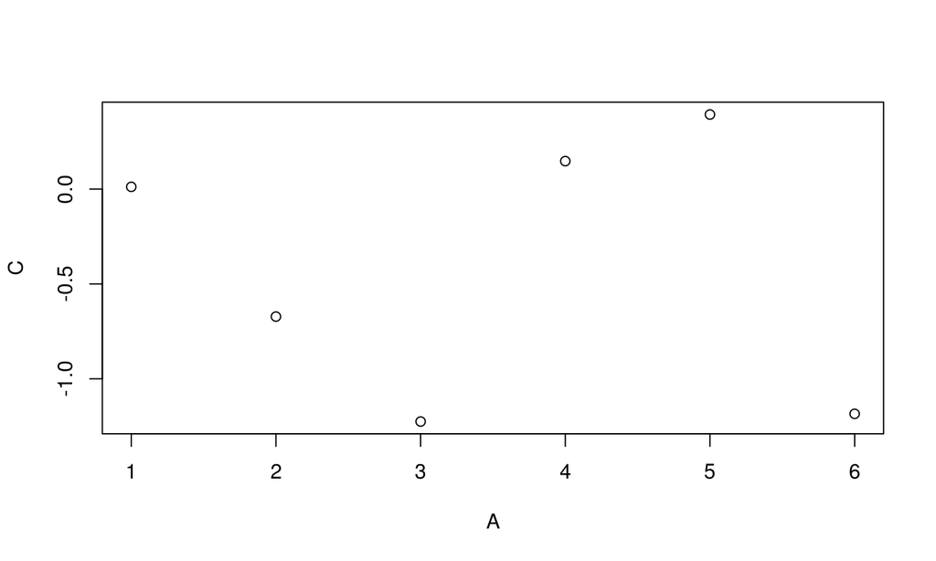

```r
DT[, plot(A,C)]
```

## Anything!!!

```
## [1] 1 2 3 4 5 6
```

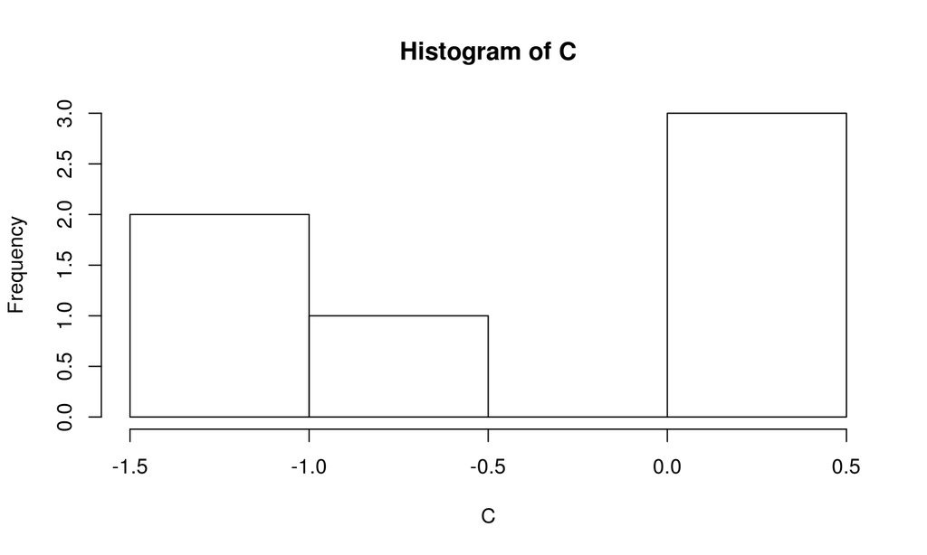

```r
DT[, { print(A)
       hist(C)
       NULL}]
```

## Group By

```r
(DT <- data.table(
  A = c("c","a","b") ,
  B =1:6 ))
```

```
##    A B
## 1: c 1
## 2: a 2
## 3: b 3
## 4: c 4
## 5: a 5
## 6: b 6
```

```r
DT[,.(MySum = sum(B),
      MyMean = mean(B)),
   by =.(A)]
```

```
##    A MySum MyMean
## 1: c     5    2.5
## 2: a     7    3.5
## 3: b     9    4.5
```

## Group By

Functions on by stament

```r
(DT <- data.table(
  A = 1:5 ,
  B =10:14 ))
```

```
##    A  B
## 1: 1 10
## 2: 2 11
## 3: 3 12
## 4: 4 13
## 5: 5 14
```

```r
DT[,.(MySum = sum(B)),
   by =.(Grp =A%%2)]
```

```
##    Grp MySum
## 1:   1    36
## 2:   0    24
```

## Group By

\(.( )\) is not necesari if we don't care about output column names

Also we can subset the aggregation

```r
DT[,sum(B),by =A%%2]
```

```
##    A V1
## 1: 1 36
## 2: 0 24
```

```r
DT[2:4,sum(B),by =A%%2]
```

```
##    A V1
## 1: 0 24
## 2: 1 12
```

Attention: ordered by order of appearance which comes in the original data.table

## Symbols

All symbols (.N,.SD,.I,.BY,.GRP,.EACHI)

X

| x | y |
| --- | --- |
| A | 2 |
| A | 5 |
| B | 7 |
| B | 1 |
| B | 9 |

Y

| z | n |
| --- | --- |
| A | 1 |
| B | 2 |

## .N

```r
X <-  data.table(x=c("A","A","B","B","B"),y=c(2,5,7,1,9),key="x")
Y <-  data.table(z=c("A","B"),n=c(1,2),key="z")
X[,.N,by=x]
```

```
##    x N
## 1: A 2
## 2: B 3
```

## .SD

"Subset of Data.table"

```r
X[,print(.SD),by=x]
```

```
##    y
## 1: 2
## 2: 5
##    y
## 1: 7
## 2: 1
## 3: 9
```

```
## Empty data.table (0 rows) of 1 col: x
```

## .I

index of DT (or wich?)

```r
X[x=="A",.I]
```

```
## [1] 1 2
```

```r
X[x=="B",.I]
```

```
## [1] 1 2 3
```

```r
X[,.I[x=="B"]]
```

```
## [1] 3 4 5
```

## .BY

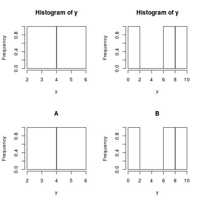

```r
X[,.(hist(y)),by=x]
X[,.(hist(y,main=paste(.BY))),by=x]
```

## .EACHI

```r
X[Y,head(.SD,n),by=.EACHI]
```

```
##    x y
## 1: A 2
## 2: B 7
## 3: B 1
```

## Programatically vary by

```r
DT <- data.table(x=c("B","A","B","A","B"),y=c(7,2,1,5,9))
bys = list ( quote(y%%2),
 quote(x),
 quote(y%%3) )

for (this in bys)
 print(DT[,sum(y),by=eval(this)])
```

```
##    this V1
## 1:    1 22
## 2:    0  2
##    this V1
## 1:    B 17
## 2:    A  7
##    this V1
## 1:    1  8
## 2:    2  7
## 3:    0  9
```

## Programatically vary selection get()

```r
DT$x
```

```
## [1] "B" "A" "B" "A" "B"
```

```r
DT[,x]
```

```
## [1] "B" "A" "B" "A" "B"
```

```r
DT[,get("x")]
```

```
## [1] "B" "A" "B" "A" "B"
```

## Programatically vary selection with=F

```r
DT[,"x"]
```

```
## [1] "x"
```

```r
DT[,"x",with=F]
```

```
##    x
## 1: B
## 2: A
## 3: B
## 4: A
## 5: B
```

```r
DT[,1]
```

```
## [1] 1
```

```r
DT[,1,with=F]
```

```
##    x
## 1: B
## 2: A
## 3: B
## 4: A
## 5: B
```

## Sort

The 3rd highest voted [R] question (of 43k):

How to sort a dataframe by column(s) in R (*)

```r
system.time( { DF[ with(DF, order(-C, B)), ] } )
```

```
##    user  system elapsed
##   1.401   0.000   1.401
```

- vs -

```r
system.time( { DT2[ order(-C, B) ] } )
```

```
##    user  system elapsed
##   0.121   0.009   0.129
```

## Performance

```r
library(dplyr)
```

```r
N=2e7; K=99
DT <- data.table(
  id1 = sample(sprintf("i%03d",1:K), N, TRUE),    # large groups (char)
  id2 = sample(sprintf("i%03d",1:K), N, TRUE),    # large groups (char)
  id3 = sample(sprintf("i%06d",1:(N/K)), N, TRUE), # small groups (char)
  id4 = sample(K, N, TRUE),                     # large groups (int)
  id5 = sample(K, N, TRUE),                     # large groups (int)
  id6 = sample(N/K, N, TRUE),                   # small groups (int)
  v1 =  sample(5, N, TRUE),                     # int in range [1,5]
  v2 =  sample(5, N, TRUE),                     # int in range [1,5]
  v3 =  sample(round(100*runif(100),4), N, TRUE))# numeric e.g. 23.5749
DF <- as.data.frame(DT)
```

```r
cat("GB =", round(object.size(DT)/1073741824, 3), "\n")
```

```
## GB = 0.978
```

## Char groups

Large groups

```r
  DT[, sum(v1), keyby="id1,id2"]
```

```
##    user  system elapsed
##   0.549   0.013   0.560
```

```r
  DF %>% group_by(id1,id2) %>%
    summarise(sum(v1))
```

```
##    user  system elapsed
##   2.088   0.031   2.122
```

Small groups

```r
  DT[, list(sum(v1),mean(v3)), keyby=id3]
```

```
##    user  system elapsed
##   0.957   0.012   0.968
```

```r
  DF %>% group_by(id3) %>%
    summarise(sum(v1),mean(v3))
```

```
##    user  system elapsed
##  10.000   0.037  10.032
```

## Integer groups

Large groups

```r
  DT[, lapply(.SD, mean), keyby=id4,
   .SDcols=7:9]
```

```
##    user  system elapsed
##   0.425   0.004   0.428
```

```r
  DF %>% group_by(id4) %>%
    summarise_each(funs(mean), 7:9)
```

```
##    user  system elapsed
##   1.185   0.024   1.208
```

Small groups

```r
  DT[, lapply(.SD, sum), keyby=id6,
   .SDcols=7:9]
```

```
##    user  system elapsed
##   0.846   0.008   0.855
```

```r
 DF %>% group_by(id6) %>%
  summarise_each(funs(sum), 7:9)
```

```
##    user  system elapsed
##   4.059   0.032   4.087
```

## set functions

In data.table, all set* functions change their input by reference.The only other data.table operator that modifies input by reference is :=. No copy is made other than temporary working memory, which is as large as one column

- setattr()
- setnames()
- setcolorder()
- setkey()
- setkeyv()
- setDT()
- setorder()

## copy()

```r
 DT  <- data.table(x=c(1,2),y=c(3,4))
 DT2 <- DT
 DT[,x:=c(5,6)]
 DT
```

```
##    x y
## 1: 5 3
## 2: 6 4
```

```r
 DT2
```

```
##    x y
## 1: 5 3
## 2: 6 4
```

```r
 DT  <- data.table(x=c(1,2),y=c(3,4))
 DT2 <- copy(DT)
 DT[,x:=c(5,6)]
 DT
```

```
##    x y
## 1: 5 3
## 2: 6 4
```

```r
 DT2
```

```
##    x y
## 1: 1 3
## 2: 2 4
```

## References

- [datacamp](https://www.datacamp.com/courses/data-analysis-the-data-table-way)
- [user2014](http://user2014.stat.ucla.edu/files/tutorial_Matt.pdf)
- [benchmarks](https://github.com/Rdatatable/data.table/wiki/Benchmarks-%3A-Grouping)
- [Pakage pdf](https://cran.r-project.org/web/packages/data.table/data.table.pdf)
- [Pakage wiki](https://github.com/Rdatatable/data.table/wiki)
- [Slides](https://github.com/jpuigde/Rdatatable)